# Mixture model for blocked ring canals

Jonathan Harrison

24/09/2018

# Blocking of Ring canals

## Forward simulating

Forward simulating from the model suggests that blocking of ring canals could account for differences between observations and observed counts of mRNA particles in cells far from the oocyte.

[output not shown]

[output cut: 4565 more lines]

[output not shown]

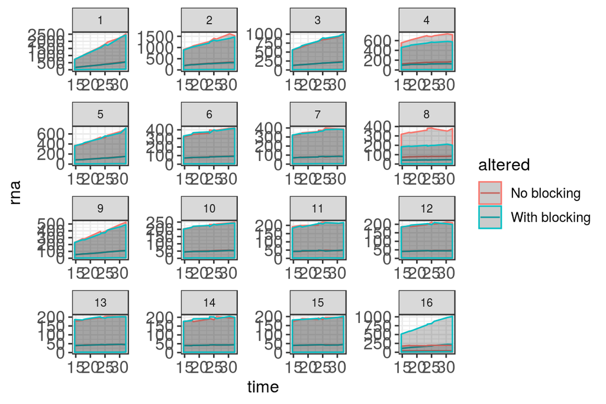

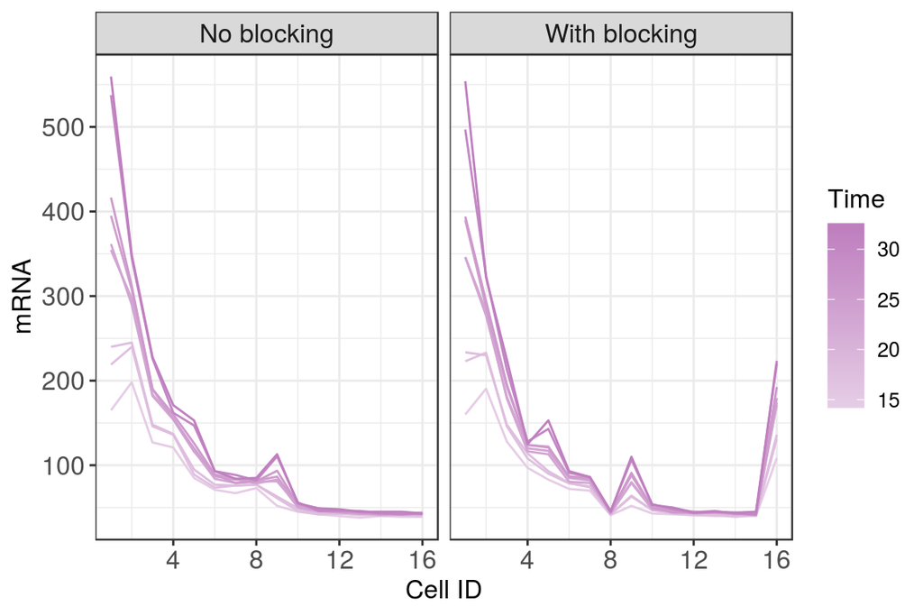

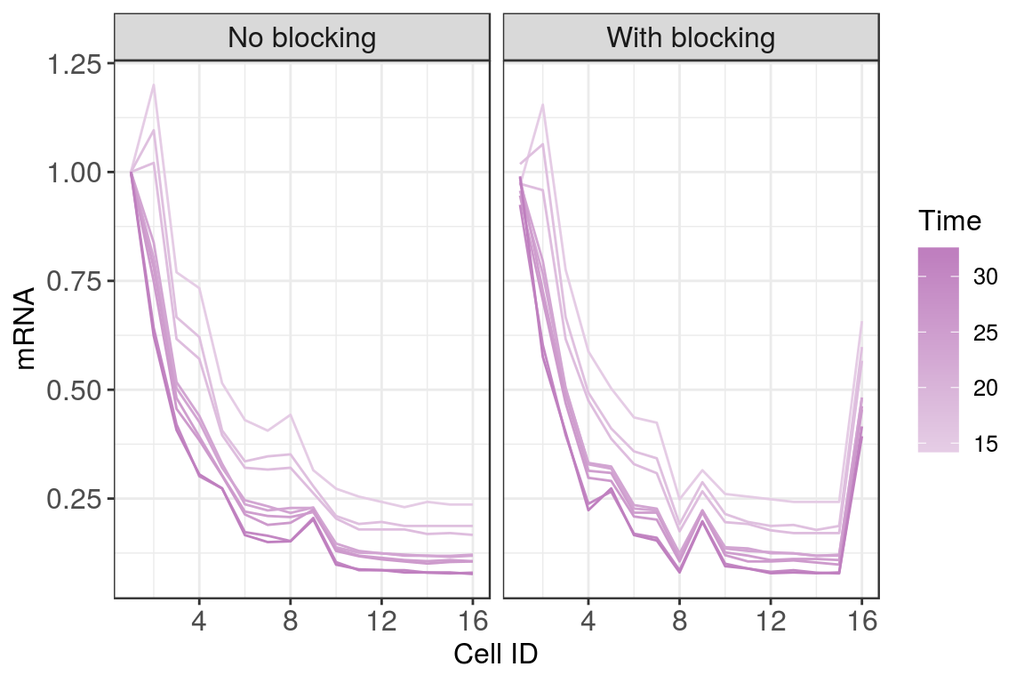

## Mixture model

Blocking each of the 15 ring canals, or not blocking any, results in different distributions of mRNA across the cells in the tissue at steady state. We consider using this blocking mechanism as a more mechanistic noise model.

We fit a mixture model with 16 hidden states corresponding to which (if any) ring canal is blocked. We marginalise over the hidden states by summing over these states and infer the ring canal transport bias, $\nu$. The model is as follows:
$$\begin{align} p(\nu | \mathbf{y}) &\propto p(\mathbf{y} | \nu) p(\nu) \\
&= \sum_{z=1}^{16} \theta_z p(\mathbf{y} | \nu, z) p(\nu) \\
&= \sum_{z=1}^{16} \theta_z N(\mathbf{y} \, | \, \mathbf{k}_z(\nu)) p(\nu) \\
\end{align}$$

where $\mathbf{y}$ is the observed mRNA counts across cells, $z \in \{ 1,2, \dots, 16\}$, $\nu$ is the transport bias, $\mathbf{k}$ is the steady state distribution of mRNA across cells predicted from the model when blocking the $z$th ring canal, and $\theta_z$ are the mixture weights.

## Observed distribution of RNA across cells

To illustrate these ideas, we plot the RNA distributions for WT and OE based on observed data.

```
## [1] "swapped"
```

```
## [1]  0.00001  2.40820 12.43159 14.79800 19.54926 21.98536 22.69240 22.81189
## [9] 24.29904
```

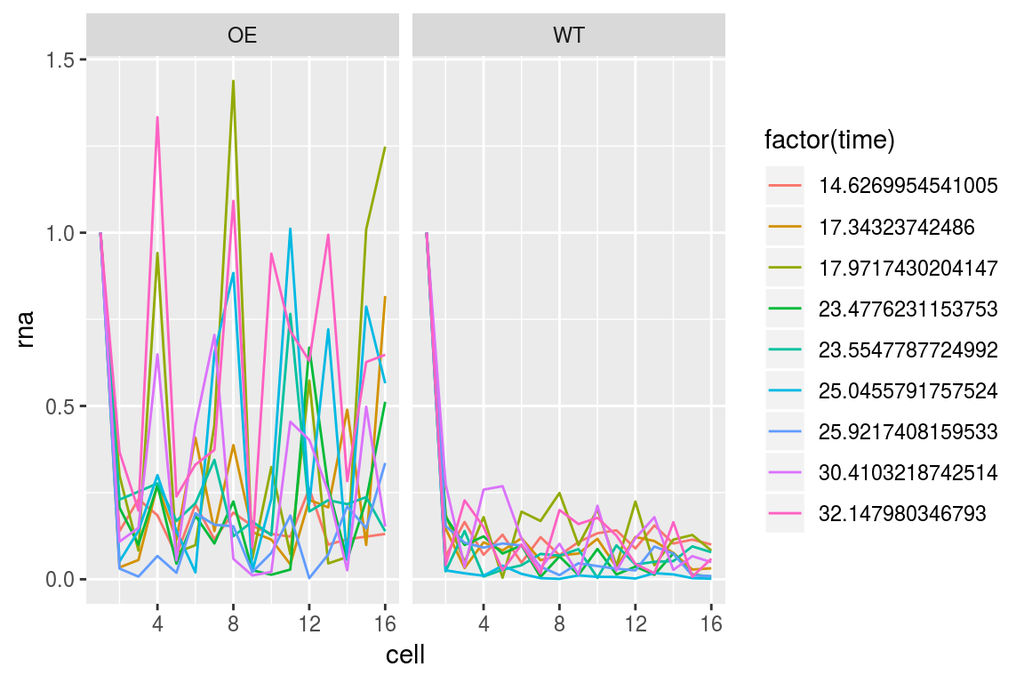

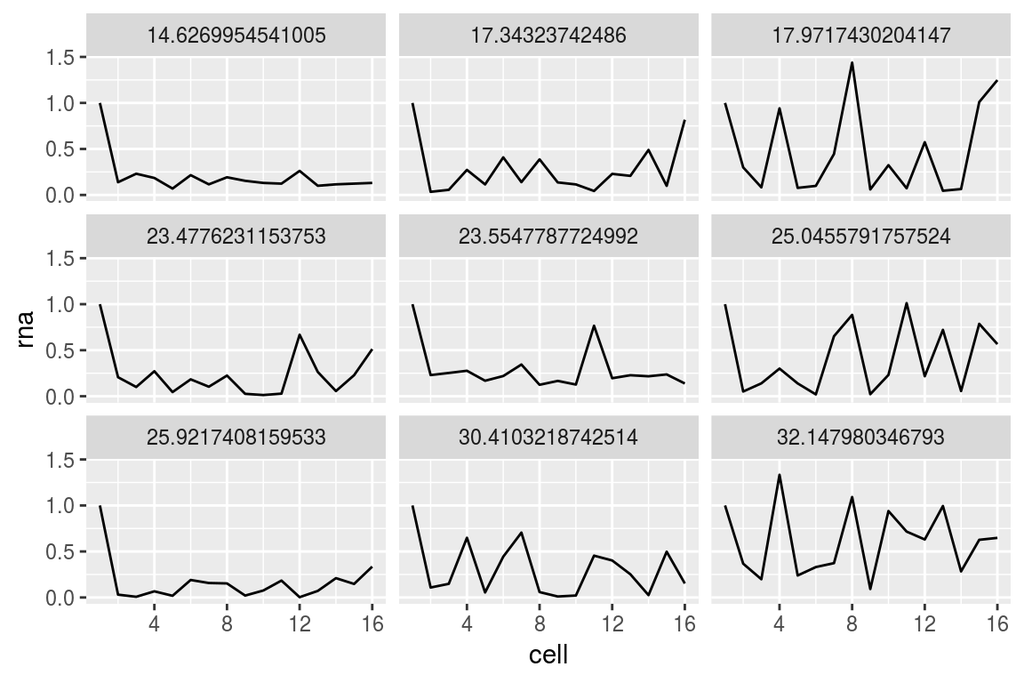

## Simulated distribution of RNA across cells

We can generate similar distributions from the mixture model. In the plot below, we show the distribution characteristic of each of the 16 states in the mixture corresponding to blocking a different ring canal (or no blocking).

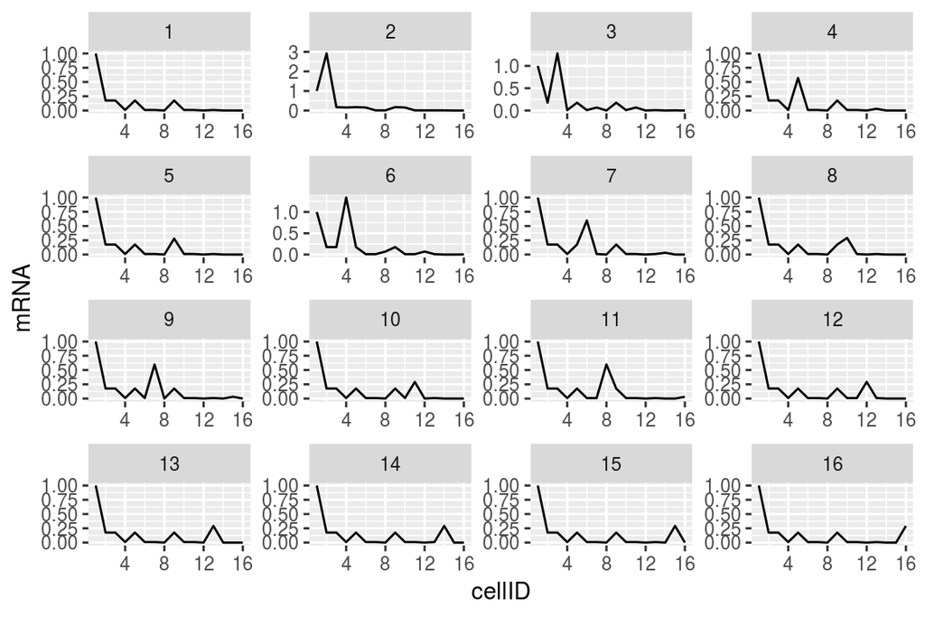

## Using the mixture model as a measurement error model

By considering the distribution of RNA across cells at steady state, we were able to infer the transport bias $\nu$ for transport through ring canals. In order to simulate data similar to the overexpression data, this model must be dominated by a large value of the noise. The measurement noise we use is not very mechanistic - simply Gaussian noise here. Since we have proposed a biological mechanism leading to this noise, we instead consider using this to motivate a different measurement error model. We use a mixture model and sum over all the possible blocked ring canals to enable to infer the transport bias $\nu$ as usual.
$$p(\nu | \mathbf{y}) \propto \sum_{j=1}^{16} p(\mathbf{y} | \nu, j) p(\nu),$$
where $p(\mathbf{y} | \nu, j)$ is the probability of oberving a distribution of RNA $\mathbf{y}$ given a transport bias of $\nu$ and the $j$th ring canal is blocked.

```
## [1] "using real data \n"
## [1] "swapped"
## [1]  0.00001  2.40820 12.43159 14.79800 19.54926 21.98536 22.69240 22.81189
## [9] 24.29904
## [1] 9
## Inference for Stan model: model_comparison_at_stst4.
## 4 chains, each with iter=2000; warmup=1000; thin=1;
## post-warmup draws per chain=1000, total post-warmup draws=4000.
##
##     mean se_mean   sd 2.5%  25%  50%  75% 97.5% n_eff Rhat
## nu  0.87       0 0.03 0.80 0.85 0.88 0.90  0.94  2895    1
## xi  0.36       0 0.02 0.33 0.35 0.36 0.37  0.39  4000    1
## phi 0.30       0 0.03 0.23 0.27 0.30 0.32  0.37  3112    1
##
## Samples were drawn using NUTS(diag_e) at Fri Sep 21 19:08:34 2018.
## For each parameter, n_eff is a crude measure of effective sample size,
## and Rhat is the potential scale reduction factor on split chains (at
## convergence, Rhat=1).
```

```
## Inference for Stan model: model_comparison_at_stst4.
## 4 chains, each with iter=2000; warmup=1000; thin=1;
## post-warmup draws per chain=1000, total post-warmup draws=4000.
##
##           mean se_mean   sd 2.5%  25%  50%  75% 97.5% n_eff Rhat
## theta[1]  0.44       0 0.08 0.28 0.39 0.44 0.50  0.60  4000    1
## theta[2]  0.03       0 0.03 0.00 0.01 0.02 0.04  0.09  4000    1
## theta[3]  0.03       0 0.02 0.00 0.01 0.02 0.04  0.09  4000    1
## theta[4]  0.03       0 0.02 0.00 0.01 0.02 0.04  0.09  4000    1
## theta[5]  0.03       0 0.03 0.00 0.01 0.02 0.04  0.10  4000    1
## theta[6]  0.05       0 0.04 0.01 0.03 0.05 0.07  0.14  4000    1
## theta[7]  0.03       0 0.03 0.00 0.01 0.02 0.04  0.10  4000    1
## theta[8]  0.03       0 0.03 0.00 0.01 0.02 0.04  0.10  4000    1
## theta[9]  0.04       0 0.04 0.00 0.02 0.03 0.06  0.14  4000    1
## theta[10] 0.04       0 0.04 0.00 0.01 0.03 0.06  0.14  4000    1
## theta[11] 0.08       0 0.05 0.01 0.04 0.07 0.10  0.18  4000    1
## theta[12] 0.04       0 0.04 0.00 0.01 0.03 0.06  0.13  4000    1
## theta[13] 0.03       0 0.03 0.00 0.01 0.02 0.04  0.11  4000    1
## theta[14] 0.03       0 0.03 0.00 0.01 0.02 0.04  0.11  4000    1
## theta[15] 0.03       0 0.03 0.00 0.01 0.02 0.05  0.12  4000    1
## theta[16] 0.05       0 0.04 0.00 0.02 0.04 0.07  0.15  4000    1
##
## Samples were drawn using NUTS(diag_e) at Fri Sep 21 19:08:34 2018.
## For each parameter, n_eff is a crude measure of effective sample size,
## and Rhat is the potential scale reduction factor on split chains (at
## convergence, Rhat=1).
```

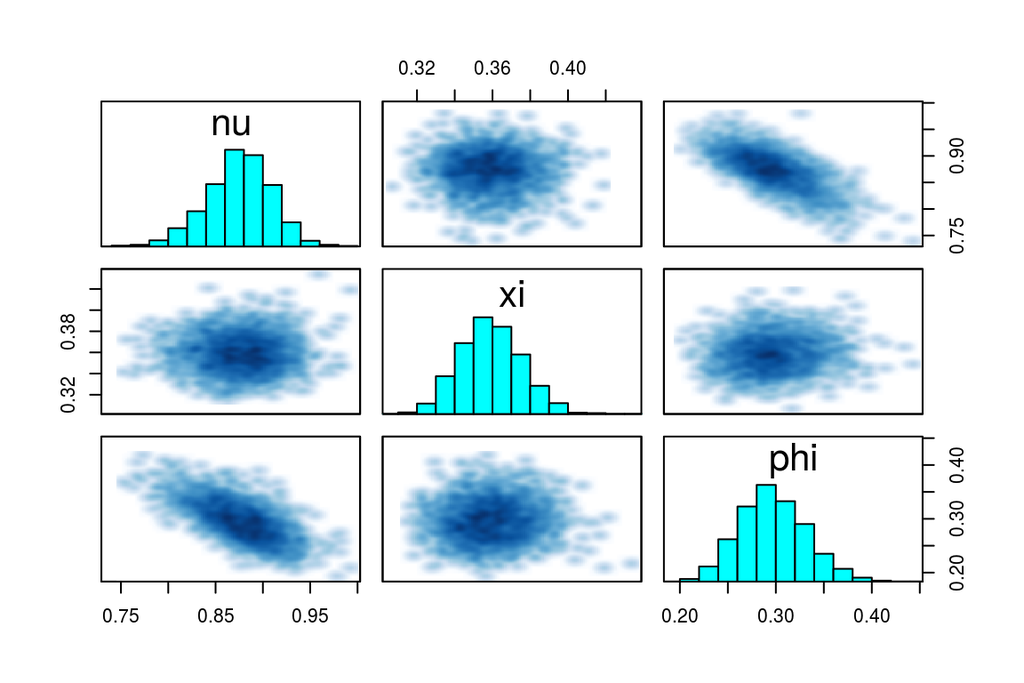

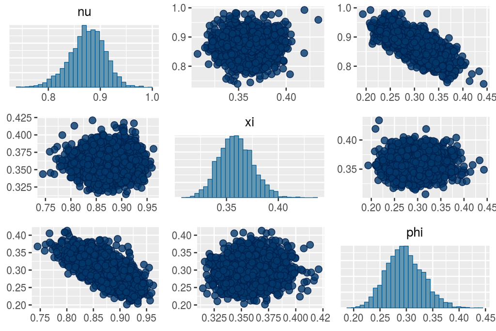

## Model comparison to compare blocking to no blocking

```
## [1] "using real data \n"
## [1] "swapped"
## [1]  0.00001  2.40820 12.43159 14.79800 19.54926 21.98536 22.69240 22.81189
## [9] 24.29904
## [1] 9
## Inference for Stan model: model_comparison_at_stst2.
## 4 chains, each with iter=2000; warmup=1000; thin=1;
## post-warmup draws per chain=1000, total post-warmup draws=4000.
##
##     mean se_mean   sd 2.5%  25%  50%  75% 97.5% n_eff Rhat
## nu  0.99       0 0.01 0.96 0.98 0.99 1.00  1.00  3711    1
## xi  0.40       0 0.02 0.36 0.38 0.40 0.41  0.45  3078    1
## phi 0.30       0 0.04 0.23 0.28 0.30 0.33  0.38  3159    1
##
## Samples were drawn using NUTS(diag_e) at Wed Sep 26 10:49:00 2018.
## For each parameter, n_eff is a crude measure of effective sample size,
## and Rhat is the potential scale reduction factor on split chains (at
## convergence, Rhat=1).
```

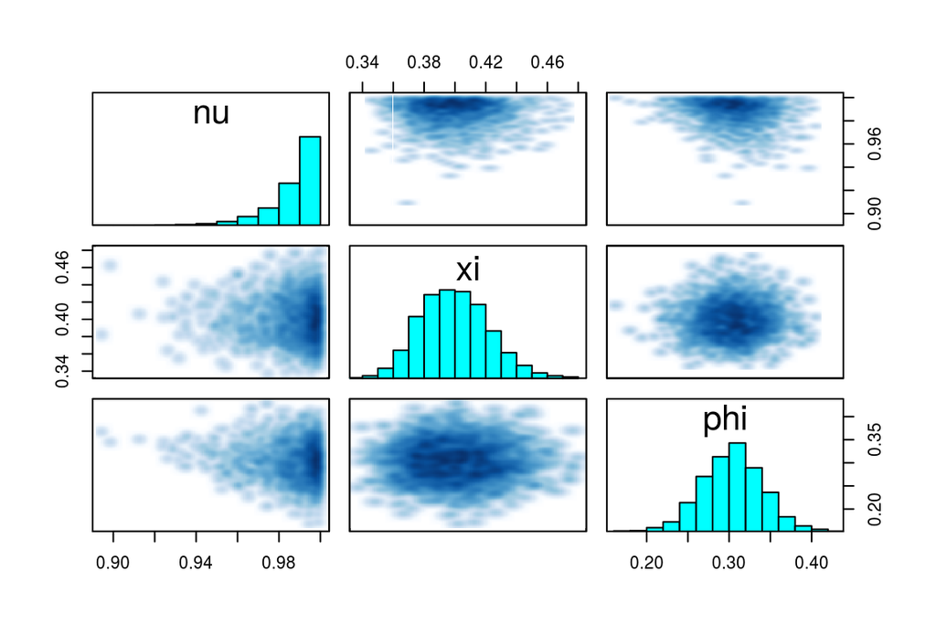

```
##
## Computed from 4000 by 9 log-likelihood matrix
##
##          Estimate   SE
## elpd_loo    -45.1 14.7
## p_loo         2.2  1.0
## looic        90.2 29.4
## ------
## Monte Carlo SE of elpd_loo is 0.0.
##
## All Pareto k estimates are good (k < 0.5).
## See help('pareto-k-diagnostic') for details.
```

```
## [1] "using real data \n"
## [1] "swapped"
## [1]  0.00001  2.40820 12.43159 14.79800 19.54926 21.98536 22.69240 22.81189
## [9] 24.29904
## [1] 9
## Inference for Stan model: model_comparison_at_stst4.
## 4 chains, each with iter=2000; warmup=1000; thin=1;
## post-warmup draws per chain=1000, total post-warmup draws=4000.
##
##     mean se_mean   sd 2.5%  25%  50%  75% 97.5% n_eff Rhat
## nu  0.48       0 0.06 0.39 0.45 0.48 0.52  0.61  2751    1
## xi  0.31       0 0.03 0.25 0.29 0.31 0.33  0.38  4000    1
## phi 0.34       0 0.03 0.27 0.32 0.35 0.37  0.41  4000    1
##
## Samples were drawn using NUTS(diag_e) at Wed Sep 26 12:43:32 2018.
## For each parameter, n_eff is a crude measure of effective sample size,
## and Rhat is the potential scale reduction factor on split chains (at
## convergence, Rhat=1).
```

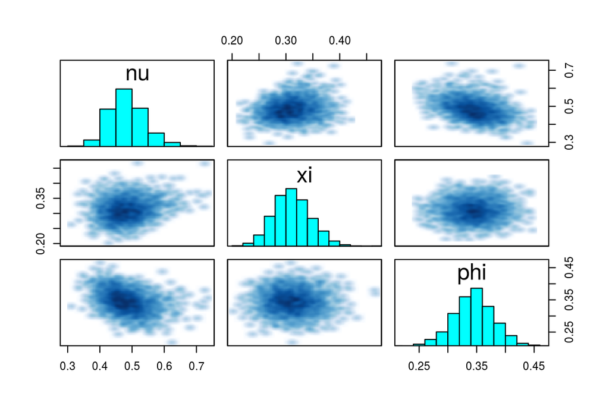

```
##
## Computed from 4000 by 9 log-likelihood matrix
##
##          Estimate   SE
## elpd_loo    -35.9  7.9
## p_loo         4.3  1.4
## looic        71.7 15.8
## ------
## Monte Carlo SE of elpd_loo is 0.1.
##
## Pareto k diagnostic values:
##                          Count Pct.    Min. n_eff
## (-Inf, 0.5]   (good)     8     88.9%   1243
##  (0.5, 0.7]   (ok)       1     11.1%   262
##    (0.7, 1]   (bad)      0      0.0%   <NA>
##    (1, Inf)   (very bad) 0      0.0%   <NA>
##
## All Pareto k estimates are ok (k < 0.7).
## See help('pareto-k-diagnostic') for details.
```

```
## elpd_diff        se
##       9.2       7.9
```

```
## [1] "using real data \n"
## [1] "swapped"
## [1]  0.00001  2.40820 12.43159 14.79800 19.54926 21.98536 22.69240 22.81189
## [9] 24.29904
## [1] 9
## Inference for Stan model: model_comparison_at_stst4.
## 4 chains, each with iter=2000; warmup=1000; thin=1;
## post-warmup draws per chain=1000, total post-warmup draws=4000.
##
##     mean se_mean   sd 2.5%  25%  50%  75% 97.5% n_eff Rhat
## nu  0.48       0 0.06 0.39 0.45 0.48 0.52  0.61  2751    1
## xi  0.31       0 0.03 0.25 0.29 0.31 0.33  0.38  4000    1
## phi 0.34       0 0.03 0.27 0.32 0.35 0.37  0.41  4000    1
##
## Samples were drawn using NUTS(diag_e) at Wed Sep 26 12:43:32 2018.
## For each parameter, n_eff is a crude measure of effective sample size,
## and Rhat is the potential scale reduction factor on split chains (at
## convergence, Rhat=1).
```

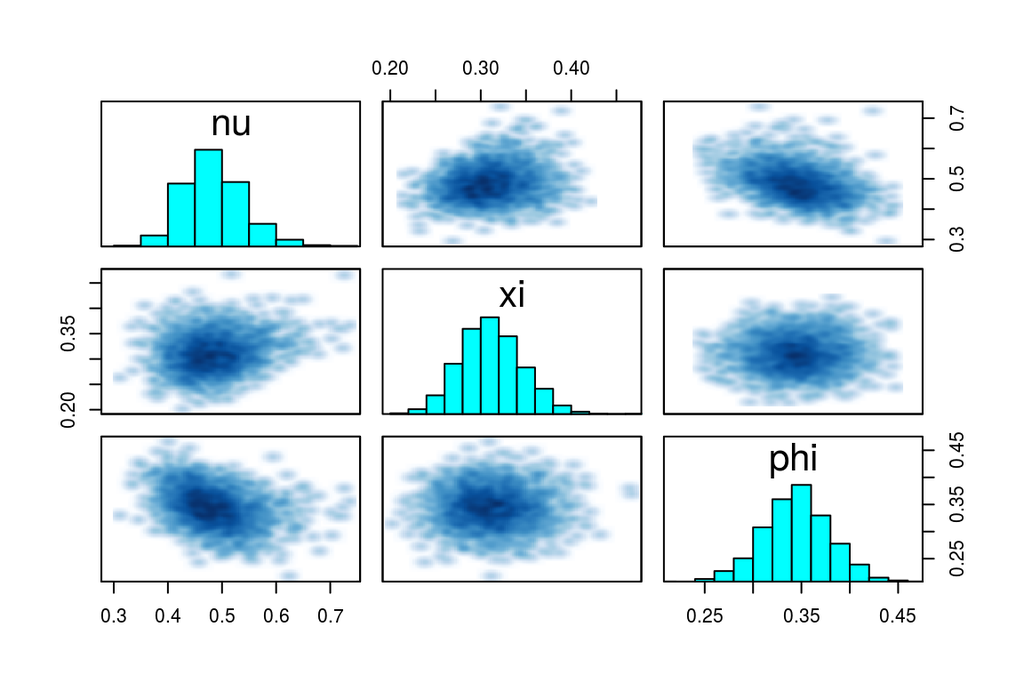

```
##
## Computed from 4000 by 9 log-likelihood matrix
##
##          Estimate   SE
## elpd_loo    -35.9  7.9
## p_loo         4.3  1.4
## looic        71.7 15.8
## ------
## Monte Carlo SE of elpd_loo is 0.1.
##
## Pareto k diagnostic values:
##                          Count Pct.    Min. n_eff
## (-Inf, 0.5]   (good)     8     88.9%   1243
##  (0.5, 0.7]   (ok)       1     11.1%   262
##    (0.7, 1]   (bad)      0      0.0%   <NA>
##    (1, Inf)   (very bad) 0      0.0%   <NA>
##
## All Pareto k estimates are ok (k < 0.7).
## See help('pareto-k-diagnostic') for details.
```

```
## Inference for Stan model: model_comparison_at_stst4.
## 4 chains, each with iter=2000; warmup=1000; thin=1;
## post-warmup draws per chain=1000, total post-warmup draws=4000.
##
##           mean se_mean   sd 2.5%  25%  50%  75% 97.5% n_eff Rhat
## theta[1]  0.47       0 0.09  0.3 0.41 0.47 0.53  0.65  4000    1
## theta[2]  0.03       0 0.03  0.0 0.01 0.02 0.04  0.11  4000    1
## theta[3]  0.03       0 0.03  0.0 0.01 0.02 0.04  0.11  4000    1
## theta[4]  0.03       0 0.03  0.0 0.01 0.02 0.04  0.11  4000    1
## theta[5]  0.03       0 0.03  0.0 0.01 0.02 0.05  0.12  4000    1
## theta[6]  0.06       0 0.05  0.0 0.02 0.05 0.08  0.17  4000    1
## theta[7]  0.03       0 0.03  0.0 0.01 0.02 0.04  0.11  4000    1
## theta[8]  0.03       0 0.03  0.0 0.01 0.02 0.04  0.11  4000    1
## theta[9]  0.03       0 0.03  0.0 0.01 0.02 0.04  0.11  4000    1
## theta[10] 0.03       0 0.03  0.0 0.01 0.02 0.04  0.11  4000    1
## theta[11] 0.06       0 0.05  0.0 0.03 0.05 0.09  0.18  4000    1
## theta[12] 0.03       0 0.03  0.0 0.01 0.02 0.04  0.11  4000    1
## theta[13] 0.03       0 0.03  0.0 0.01 0.02 0.04  0.11  4000    1
## theta[14] 0.03       0 0.03  0.0 0.01 0.02 0.04  0.11  4000    1
## theta[15] 0.03       0 0.03  0.0 0.01 0.02 0.04  0.12  4000    1
## theta[16] 0.04       0 0.04  0.0 0.01 0.03 0.05  0.13  4000    1
##
## Samples were drawn using NUTS(diag_e) at Wed Sep 26 12:43:32 2018.
## For each parameter, n_eff is a crude measure of effective sample size,
## and Rhat is the potential scale reduction factor on split chains (at
## convergence, Rhat=1).
```